# FML_Assignment_4

2024-03-14

# Cluster Analysis of Pharmaceutical Firms

## Introduction

### In this analysis, we perform cluster analysis on a dataset containing information about pharmaceutical firms. We focus on using numerical variables (1 to 9) to cluster the 21 firms. Various choices made in conducting the cluster analysis, such as weights for different variables, the specific clustering algorithm(s) used, the number of clusters formed, are justified.

```r
#Importing Required Packages
library(readr)
#Importing Data Set
data <- read_csv("/Users/meghana/Downloads/Pharmaceuticals.csv")
```

### Load necessary libraries

```r
library("ggplot2")
library("factoextra")
library("flexclust")
library("cluster")
library("tidyverse")
library("cluster")
```

#### Question(A) Use only the numerical variables (1 to 9) to cluster the 21 firms. Justify the various choices made in conducting the cluster analysis, such as weights for different variables, the specific clustering algorithm(s) used, the number of clusters formed, and so on.

```r
# Removing null values in data (data cleaning)
Pharma_data =  na.omit(data)
Pharma_data
```

```
## # A tibble: 21 × 14
##    Symbol Name     Market_Cap  Beta PE_Ratio   ROE   ROA Asset_Turnover Leverage
##    <chr>  <chr>         <dbl> <dbl>    <dbl> <dbl> <dbl>          <dbl>    <dbl>
##  1 ABT    Abbott …      68.4   0.32     24.7  26.4  11.8            0.7     0.42
##  2 AGN    Allerga…       7.58  0.41     82.5  12.9   5.5            0.9     0.6
##  3 AHM    Amersha…       6.3   0.46     20.7  14.9   7.8            0.9     0.27
##  4 AZN    AstraZe…      67.6   0.52     21.5  27.4  15.4            0.9     0
##  5 AVE    Aventis       47.2   0.32     20.1  21.8   7.5            0.6     0.34
##  6 BAY    Bayer AG      16.9   1.11     27.9   3.9   1.4            0.6     0
##  7 BMY    Bristol…      51.3   0.5      13.9  34.8  15.1            0.9     0.57
##  8 CHTT   Chattem…       0.41  0.85     26    24.1   4.3            0.6     3.51
##  9 ELN    Elan Co…       0.78  1.08      3.6  15.1   5.1            0.3     1.07
## 10 LLY    Eli Lil…      73.8   0.18     27.9  31    13.5            0.6     0.53
## # ℹ 11 more rows
## # ℹ 5 more variables: Rev_Growth <dbl>, Net_Profit_Margin <dbl>,
## #   Median_Recommendation <chr>, Location <chr>, Exchange <chr>
```

```r
row.names <- Pharma_data[,1]
pharma_data1 <- Pharma_data[,3:11]#numerical variable from 3 to 11
head(pharma_data1)
```

```
## # A tibble: 6 × 9
##   Market_Cap  Beta PE_Ratio   ROE   ROA Asset_Turnover Leverage Rev_Growth
##        <dbl> <dbl>    <dbl> <dbl> <dbl>          <dbl>    <dbl>      <dbl>
## 1      68.4   0.32     24.7  26.4  11.8            0.7     0.42       7.54
## 2       7.58  0.41     82.5  12.9   5.5            0.9     0.6        9.16
## 3       6.3   0.46     20.7  14.9   7.8            0.9     0.27       7.05
## 4      67.6   0.52     21.5  27.4  15.4            0.9     0         15
## 5      47.2   0.32     20.1  21.8   7.5            0.6     0.34      26.8
## 6      16.9   1.11     27.9   3.9   1.4            0.6     0         -3.17
## # ℹ 1 more variable: Net_Profit_Margin <dbl>
```

```r
pharma_data2 <- scale(pharma_data1)
head(pharma_data2)
```

```
##      Market_Cap        Beta    PE_Ratio         ROE        ROA Asset_Turnover
## [1,]  0.1840960 -0.80125356 -0.04671323  0.04009035  0.2416121  -5.121077e-16
## [2,] -0.8544181 -0.45070513  3.49706911 -0.85483986 -0.9422871   9.225312e-01
## [3,] -0.8762600 -0.25595600 -0.29195768 -0.72225761 -0.5100700   9.225312e-01
## [4,]  0.1702742 -0.02225704 -0.24290879  0.10638147  0.9181259   9.225312e-01
## [5,] -0.1790256 -0.80125356 -0.32874435 -0.26484883 -0.5664461  -4.612656e-01
## [6,] -0.6953818  2.27578267  0.14948233 -1.45146000 -1.7127612  -4.612656e-01
##        Leverage Rev_Growth Net_Profit_Margin
## [1,] -0.2120979 -0.5277675        0.06168225
## [2,]  0.0182843 -0.3811391       -1.55366706
## [3,] -0.4040831 -0.5721181       -0.68503583
## [4,] -0.7496565  0.1474473        0.35122600
## [5,] -0.3144900  1.2163867       -0.42597037
## [6,] -0.7496565 -1.4971443       -1.99560225
```

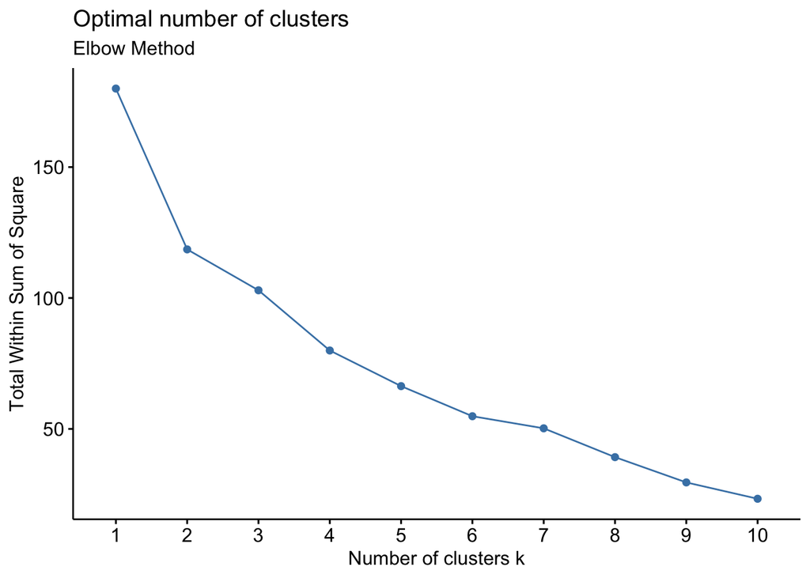

```r
#Determination of Number of Clusters
#We determine the optimal number of clusters using different methods such as the Elbow Method, Silhouette Method, and Gap Stat Method.
fviz_nbclust(pharma_data2, kmeans, method = "wss") +labs(subtitle = "Elbow Method")
```

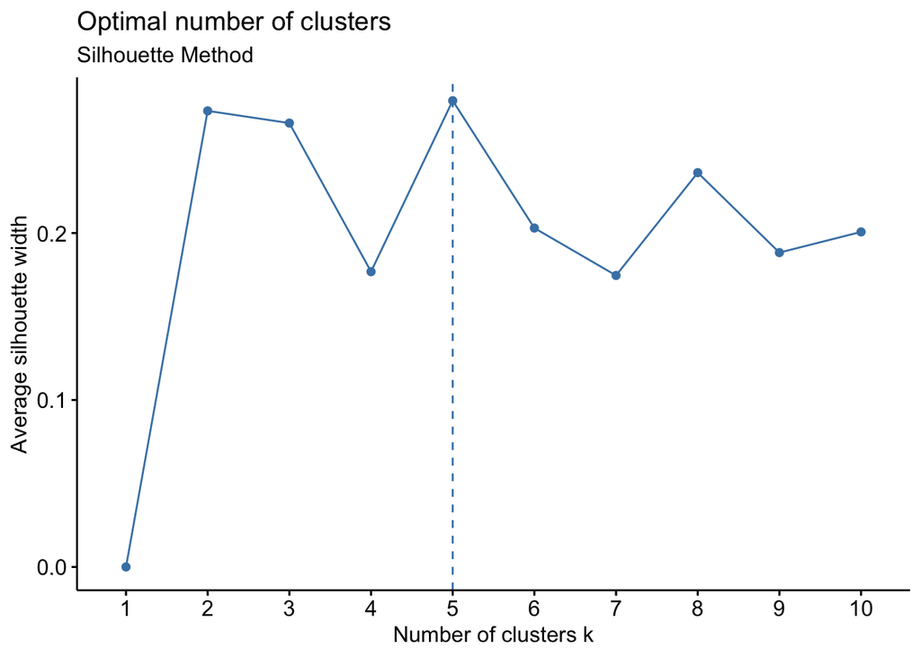

```r
fviz_nbclust(pharma_data2, kmeans, method = "silhouette") + labs(subtitle = "Silhouette Method")
```

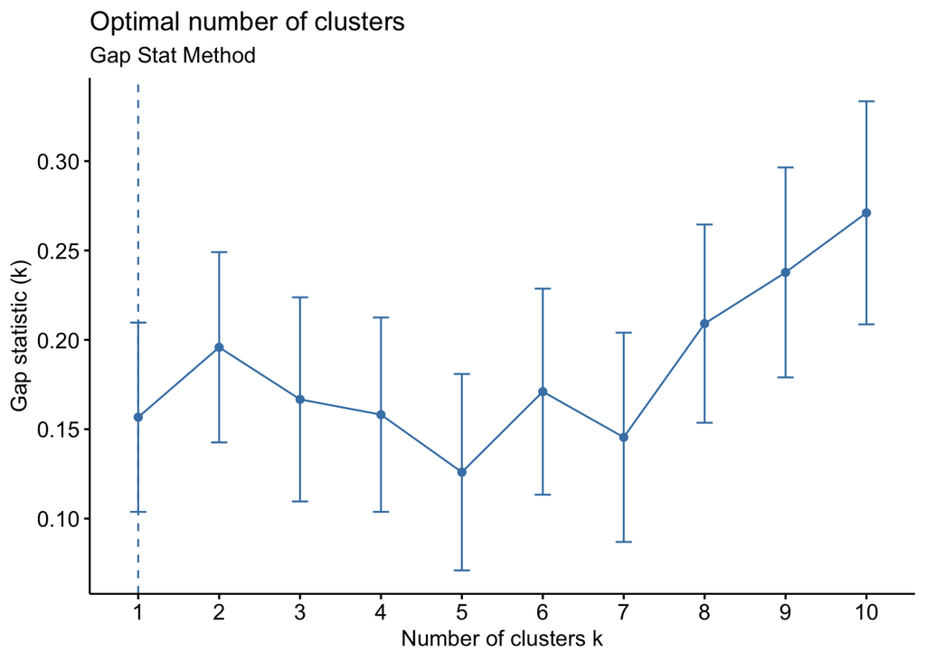

```r
fviz_nbclust(pharma_data2, kmeans, method = "gap_stat") + labs(subtitle = "Gap Stat Method")
```

```r
set.seed(64060)
k_5 <- kmeans(pharma_data2, centers = 5, nstart = 25)
k_5 $centers
```

```
##    Market_Cap       Beta    PE_Ratio        ROE        ROA Asset_Turnover
## 1 -0.87051511  1.3409869 -0.05284434 -0.6184015 -1.1928478     -0.4612656
## 2 -0.43925134 -0.4701800  2.70002464 -0.8349525 -0.9234951      0.2306328
## 3 -0.76022489  0.2796041 -0.47742380 -0.7438022 -0.8107428     -1.2684804
## 4 -0.03142211 -0.4360989 -0.31724852  0.1950459  0.4083915      0.1729746
## 5  1.69558112 -0.1780563 -0.19845823  1.2349879  1.3503431      1.1531640
##      Leverage Rev_Growth Net_Profit_Margin
## 1  1.36644699 -0.6912914      -1.320000179
## 2 -0.14170336 -0.1168459      -1.416514761
## 3  0.06308085  1.5180158      -0.006893899
## 4 -0.27449312 -0.7041516       0.556954446
## 5 -0.46807818  0.4671788       0.591242521
```

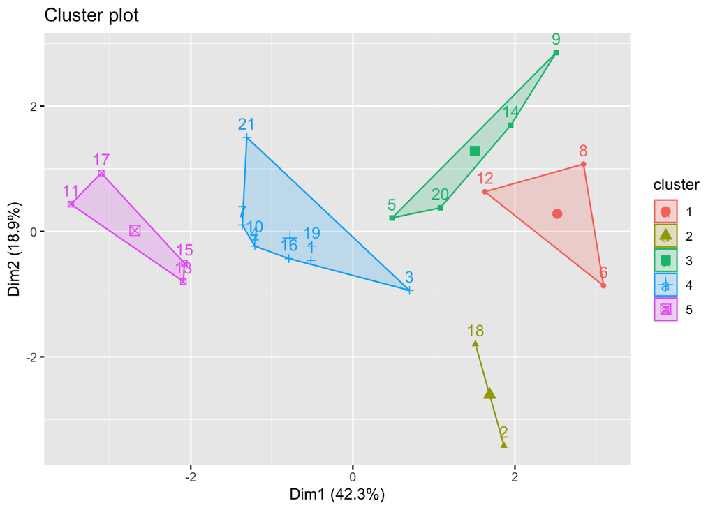

```r
fviz_cluster(k_5, data = pharma_data2)
```